# Reproducible Research: Peer Assessment 1

# Introduction

This report is the result of the Reproducible Research Peer assessment 1.

This assignment makes use of data from a personal activity monitoring device. This device collects data at 5 minute intervals through out the day. The data consists of two months of data from an anonymous individual collected during the months of October and November, 2012 and include the number of steps taken in 5 minute intervals each day.

# Some global settings and libraries

```r
library(knitr)
opts_chunk$set(echo = TRUE)
```

The lubridate lib for date manipulation

```r
library(lubridate)
```

The plot library

```r
library(ggplot2)
```

# Loading and preprocessing the data

## Looking at the data

The CSV has 3 columns:

1. steps: Number of steps taking in a 5-minute interval (missing values are coded as NA).
2. date: The date on which the measurement was taken in YYYY-MM-DD format.
3. interval: Identifier for the 5-minute interval in which measurement was taken.

## Load the data

The data is hold in activity.csv, we assume it is in the same folder as this script. We use `read.csv()` to read the file. We treat the `steps` and `interval` as numeric, `date` as a date.

We use a custom function to transform the data column into a R Date type. For that we use the `setClass` to define the new class and `setAs` as the custom function we will use in the `colClasses`. In that case we do not have to do an extra parsing of the dataset to convert the strings to dates.

```r
setClass("d_Date")
setAs("character","d_Date", function(from) as.Date(from, format="%Y-%m-%d") )
d <- read.csv('activity.csv', header = TRUE, sep = ",",colClasses=c("numeric", "d_Date", "numeric"))
```

This is how it looks like:

```r
str(d)
```

```
## 'data.frame':    17568 obs. of  3 variables:
##  $ steps   : num  NA NA NA NA NA NA NA NA NA NA ...
##  $ date    : Date, format: "2012-10-01" "2012-10-01" ...
##  $ interval: num  0 5 10 15 20 25 30 35 40 45 ...
```

# What is mean total number of steps taken per day?

As stated in the assignment we can safely ignore the missing (NA) values. We aggregate the steps per date.

```r
steps_day <- aggregate(steps ~ date,d,sum)
```

Here how it looks like:

```r
str(steps_day)
```

```
## 'data.frame':    53 obs. of  2 variables:
##  $ date : Date, format: "2012-10-02" "2012-10-03" ...
##  $ steps: num  126 11352 12116 13294 15420 ...
```

## The histogram

The frequency of the number of steps taken per day, `binwidth=2000` seems a good width for the histogram:

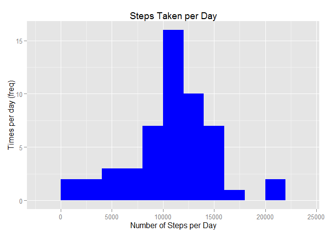

```r
ggplot(steps_day, aes(x = steps)) +
        geom_histogram(fill = "blue",binwidth=2000) +
        labs(title="Steps Taken per Day",
             x = "Number of Steps per Day",
             y = "Times per day (freq)")
```

## Mean and median of total number of steps per day

We use the standard functions to calculate the mean and median. We leave out the NA (`na.rm=TRUE`). We round to the nearest number for display and clarity. Seen the number of steps, we don’t think that “half-steps” are relevant in these results.

```r
steps_mean <- as.character(round(mean(steps_day$steps,na.rm=TRUE),0))
steps_median <- as.character(round(median(steps_day$steps,na.rm=TRUE),0))
```

1. Mean is **10766**.
2. Median is **10765**.

# What is the average daily activity pattern?

## The dataset

We make a time series plot of the 5-minute interval (x-axis) and the average number of steps taken, averaged across all days (y-axis) using the aggregate function. We do not take the empty (NA) values. We also gvive the result some meaningfull column names.

```r
steps_5min <- aggregate(d$steps, by = list(interval = d$interval),FUN=mean, na.rm=TRUE)
colnames(steps_5min) <- c("interval","steps")
```

The first rows:

```
##   interval     steps
## 1        0 1.7169811
## 2        5 0.3396226
## 3       10 0.1320755
## 4       15 0.1509434
## 5       20 0.0754717
## 6       25 2.0943396
```

## Time series plot

We use the `ggplot` with `geom_line` to display the time series:

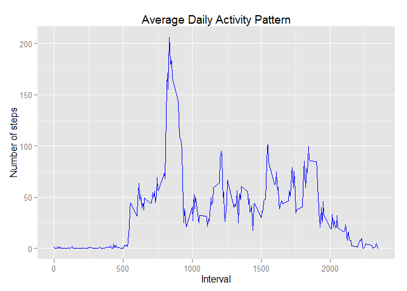

```r
ggplot(steps_5min, aes(x=steps_5min$interval, y=steps_5min$steps)) +
        geom_line(color="blue") +
        labs(title="Average Daily Activity Pattern",
             x="Interval",
             y="Number of steps")
```

## The maximum number of steps

```r
max_steps <- steps_5min[order(-steps_5min$steps),]
```

```r
missing_vals <- sum(is.na(d$steps))
```

So, the number of missing values is **2304**.

## Strategy for filling the missing values

To replace the missing values, we propose to replace them with the mean value. Anyway the mean and median are very close together as can be seen earlier in the report.

## New dataset with missing values replacement

```r
steps_mean_per_day <- as.numeric(steps_mean)/288
```

We replace the NA with 37.3819444.

```r
d[is.na(d)] <- steps_mean_per_day
```

## Impact of replacing the missing values

We use the same settings for the histogram as earlier, but this time with the updated dataset:

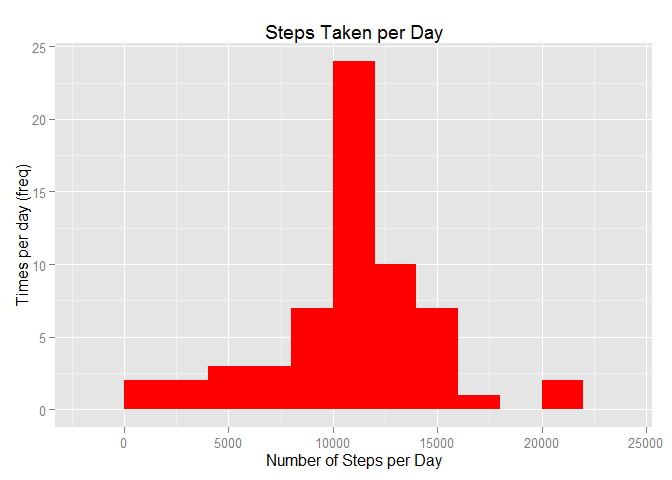

```r
steps_day_new <- aggregate(steps ~ date,d,sum)
ggplot(steps_day_new, aes(x = steps)) +
        geom_histogram(fill = "red",binwidth=2000) +
        labs(title="Steps Taken per Day",
             x = "Number of Steps per Day",
             y = "Times per day (freq)")
```

We calcute the new mean and median as follows:

```r
steps_new_mean   <- as.character(round(mean(steps_day_new$steps, na.rm=TRUE),0))
steps_new_median <- as.character(round(median(steps_day_new$steps, na.rm=TRUE),0))
```

Without the NA’s: mean = 10766 and median = 10765.

Replacing the NA’s : mean = 10766 and median = 10766.

# Differences in activity patterns between weekdays and weekends

We use the dataset with the filled-in missing values for this part.

## Creating the two level factor

We use the dataset with the replaced values. By adding a factor column stating the day of the week. We use the `wday()` function from `lubridate`. We bind a column to the dataset that returns TRUE is weekend or FALSE if weekday. Then we replace the values with **Weekend** or **Week**.

```r
week_data <- cbind(d,wday(d$date) %in% c(1,7))
colnames(week_data)<-c("steps","date","interval","weekday")
week_data$weekday[week_data$weekday == FALSE] <-"Week"
week_data$weekday[week_data$weekday == TRUE] <-"Weekend"
```

## Times series panel plot

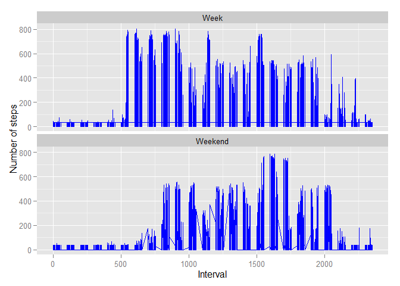

```r
ggplot(week_data, aes(x=interval, y=steps)) + geom_line(color="blue") + facet_wrap(~weekday, nrow=2, ncol=1) + labs(x="Interval", y="Number of steps")
```